# Homework for StatComp

18063

2019-01-11

## Overview

**StatComp18063** is a simple R package that is the homework for ‘Statistical Computing’ course in USTC Department of Statistics and Finance. The package include three functions and all homework for 18063.

# Homework 1

### Question

Write a .Rmd file to implement at least three examples of different types in the books “R for Beginners”(texts, numerical results, tables, and figures).

### Answer

### Example 1:

In this example, we will use the package ‘lattice’ to plot some graphs. Firstly, the package must be loaded in the memory using the command $\color{red}{\rm{'library(lattice) '}}$ so that the function of the package can be accessed.

```r
library(lattice)
```

Let’s start with the density function graph. We can use the function $\color{red}{\rm{'densityplot(\sim x)'}}$ to get this graph. In each figure, in addition to the empirical density curve, a normal density fitting curve is superimposed. This requires the argument ‘panel’ to define what to draw on each diagram.

The code is as follows:

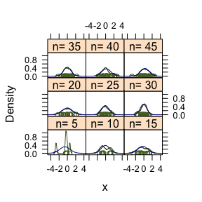

```r
n=seq(5,45,5)
x=rnorm(sum(n))
y=factor(rep(n,n),labels = paste('n=',n))
densityplot(~x|y,
            panel = function(x, ...) {
              panel.densityplot(x, col="DarkOliveGreen", ...)
              panel.mathdensity(dmath=dnorm,
                                args=list(mean=mean(x), sd=sd(x)),
                                col="darkblue")
              })
```

Then we use the dataset $\color{red}{\rm{'quakes'}}$ to show the geographical location of the earthquakes at different depths.

The code is as follows:

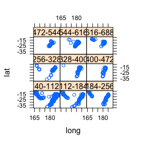

```r
data(quakes)
mini = min(quakes$depth)
maxi = max(quakes$depth)
int = ceiling((maxi - mini)/9)
inf = seq(mini, maxi, int)
quakes$depth.cat = factor(floor(((quakes$depth - mini) / int)),
labels=paste(inf, inf + int, sep="-"))
xyplot(lat ~ long | depth.cat, data = quakes)
```

### Example 2:

A simple example of variance analysis. In the package $\color{red}{\rm{'stats '}}$, we use the function $\color{red}{\rm{'aov '}}$ for variance analysis. To demonstrate this function, we use the dataset: $\color{red}{\rm{'InsectSprays '}}$.

We use the fuction $\color{red}{\rm{' data '}}$ input the dataset, the code as follows:

```r
data(InsectSprays)
aov.spray = aov(sqrt(count) ~ spray, data = InsectSprays)
aov.spray
```

```
## Call:
##    aov(formula = sqrt(count) ~ spray, data = InsectSprays)
##
## Terms:
##                    spray Residuals
## Sum of Squares  88.43787  26.05798
## Deg. of Freedom        5        66
##
## Residual standard error: 0.6283453
## Estimated effects may be unbalanced
```

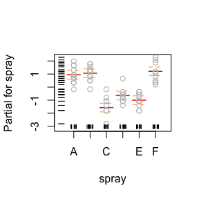

```r
termplot(aov.spray, se=TRUE, partial.resid=TRUE, rug=TRUE)
```

### Example 3:

In this example, we will show how to use the packages in R. First, we can use the function $\color{red}{\rm{' search '}}$ to show loaded packages.

```r
search()
```

```
##  [1] ".GlobalEnv"        "package:lattice"   "package:stats"
##  [4] "package:graphics"  "package:grDevices" "package:utils"
##  [7] "package:datasets"  "package:methods"   "Autoloads"
## [10] "package:base"
```

Other packages need to be loaded before they can be used:

```r
library(grid)
```

Functions that can be used in a package can be displayed in the following way:

```r
library(help = grid)
```

# Homework 2

### Question

### Exercises 3.5

A discrete random variable $X$ has probability mass function

$$\begin{equation}
\left|
\begin{array}{ll1111}
x & 0 & 1 &2 &3 &4\\
p(x)& 0.1&0.2&0.2&0.2&0.3\\
\end{array}
\right|
\end{equation}$$

Use the inverse transform method to generate a random sample of size 1000 from the distribution of $X$. Construct a relative frequency table and compare the empirical with the theoretical probabilities. Repeat using the R sample function.

## Answer

Use the inverse transform method to generate a random sample of size 1000 from the distribution of $X$.

The code is as follows:

```r
set.seed(977)   ##  set a random seed
x=c(0:4)        ## generate the x
p=c(0.1,0.2,0.2,0.2,0.3)  ## generate the probability
cp=cumsum(p)   ## give the cumulate probability
n=1000      ## set the sample of size 1000
r=numeric(n)
r=x[findInterval(runif(n),cp)+1] ## the inverse transform method
table(r) ## construct a relative frequency table
```

```
## r
##   0   1   2   3   4
## 105 188 186 210 311
```

```r
ct=as.vector(table(r))
ct/sum(ct)  ## compare the empirical probability
```

```
## [1] 0.105 0.188 0.186 0.210 0.311
```

```r
ct/sum(ct)/p  ## the ratio of emparical probability and theorical probability
```

```
## [1] 1.050000 0.940000 0.930000 1.050000 1.036667
```

According to the results above, we can see that the performence of the inverse transform method is very well.

```r
Y=p*n
counts = rbind(table(r),Y) ## combine r and Y into a data.frame
rownames(counts)=c('r','Y')  ## gives the row name of the data.frame
counts
```

```
##     0   1   2   3   4
## r 105 188 186 210 311
## Y 100 200 200 200 300
```

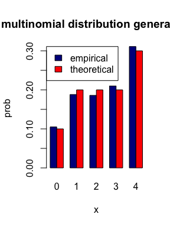

```r
barplot(counts/1000, main="multinomial distribution generation",
        xlab="x",ylab='prob', col=c("darkblue","red"),
        beside=TRUE,legend.text = c('empirical','theoretical'),
        args.legend = list(x = "topleft"))
```

### Question

### Exercises 3.7

Write a function to generate a random sample of size n from the Beta(a, b) distribution by the acceptance-rejection method. Generate a random sample of size 1000 from the Beta(3,2) distribution. Graph the histogram of the sample with the theoretical Beta(3,2) density superimposed.

## Answer

The pdf of Beta(3,2) is:
$$f(x)=12x^2(1-x), \quad 0<x<1.$$
Let $g(x)$ be the Uniform(0,1) density, then $f(x)/g(x)\leq 12$ for all $0<x<1$, so $c=12.$ A random x from $g(x)$ is accepted if
$$\frac{f(x)}{cg(x)}=\frac{12x^2(1-x)}{12(1)}=x^2(1-x)>\mu$$
The code is as follows:

```r
set.seed(53) ## set a random seed
n=1000
k=0  ## counter for accepted
j=0  ## iterations
y=numeric(n)

 while (k<n) {
  u=runif(1)
  j=j+1
  x=runif(1)  ## #random variate from g
  if(x^2*(1-x)>u) {
    k=k+1
    y[k]=x
  }
}
j
```

```
## [1] 12471
```

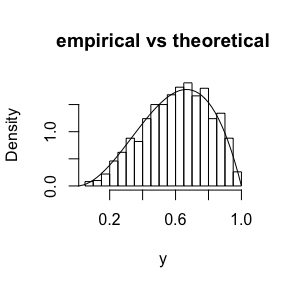

```r
hist(y,breaks=15,freq=F, main='empirical vs theoretical') ## plot the histogram
x1=seq(0,1,0.02)
y1=12*x1^2*(1-x1)
lines(x1,y1)   ## add the theoretical curve
```

In this simulation, 12471 iterations were required to generate the 1000 beta variates. According to the histogram above, we can see that the performance of Acceptance-rejection method is very well.

### Question

### Exercises 3.12

Simulate a continuous Exponential-Gamma mixture. Suppose that the rate parameter $\Lambda$ has Gamma(r,$\beta$) distribution and $Y$ has Exp($\Lambda$) distribution. That is,
$$(Y|\Lambda=\lambda)\sim f_Y(y|\lambda)=\lambda e^{-\lambda y}.$$
Generate 1000 random observationsvfrom this mixture with $r = 4$ and $\beta = 2$.

## Answer

The pdf of Gamma(4,2) is:
$$p(\lambda)=\frac{2^4}{\Gamma(4)}\lambda^3e^{-2\lambda}, \lambda>0.$$
Given the $\Lambda=\lambda$, Y has $Exp(\lambda)$ distribution. That is,
$$p(y|\Lambda=\lambda)=\lambda e^{-\lambda y}.$$

Now, we can simulate a continuous Exponential-Gamma mixture. The code is as follows:

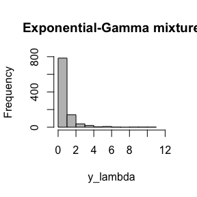

```r
#generate a Exponential-Gamma mixture
set.seed(473)
n=1000
r=4
beta=2
lambda = rgamma(n, r, beta) ## generate the $\lambda$ from the Gamma(4,2) distribution

#now supply the sample of lambda??s as the parametric of Exponential distribution

y_lambda = rexp(n, lambda) ##  generate the mixture

hist(y_lambda,col='gray',ylim=c(0,800),,xlim=c(0,12),main='Exponential-Gamma mixture')
```

# Homework 3

## Question

### Exercises 5.4

Write a function to compute a Monte Carlo estimate of the Beta(3, 3) cdf, and use the function to estimate F(x) for x = 0.1, 0.2, . . ., 0.9. Compare the estimates with the values returned by the `pbeta` function in R.

### Answer:

The pdf of Beta(3,3) is :
$$p(x)=30x^2(1-x)^2,\quad 0<x<1.$$

so, the cdf of beta(3,3) is
$$F(x)=\int_0^x 30t^2(1-t)^2 dt.$$
Let $y=t/x,$then$dt=xdy$,and
$$F(x)=\int_0^130x^3y^2(1-xy)^2dy=30\theta,$$
where $\theta=\int_0^1x^3y^2(1-xy)^2dy=E_Y[x^3Y^2(1-xY)^2], Y$ has the Uniform(0,1) distribution. Generate iid Uniform(0,1) random numbers $u_1,...,u_m$, and compute
$$\widehat{\theta}=\frac{1}{m}\sum_{i=1}^mx^3u_i^2(1-xu_i)^2.$$
The R code as follows:

```r
set.seed(432)
m=10000
u=runif(m)
##  the function to generate cdf of Beta(3,3)
CDF=function(x){
  theta_hat=mean(x^3*u^2*(1-x*u)^2)
  CDF_hat=30*theta_hat
  #print(CDF_hat)
}

q=seq(0.1,0.9,0.1)
Phi=pbeta(q,3,3)   ## q-quantile of Beta(3,3) by function 'pbeta'


##  q-quantile of Beta(3,3) by function CDF
cdf=rep(0,length(q))
for (i in 1 : length(q)) {
  cdf[i] = CDF(q[i])
  }
## Compare the estimator
print(round(rbind(q,cdf,Phi),3))
```

```
##      [,1]  [,2]  [,3]  [,4]  [,5]  [,6]  [,7]  [,8]  [,9]
## q   0.100 0.200 0.300 0.400 0.500 0.600 0.700 0.800 0.900
## cdf 0.009 0.058 0.162 0.316 0.498 0.680 0.834 0.940 0.991
## Phi 0.009 0.058 0.163 0.317 0.500 0.683 0.837 0.942 0.991
```

### Exercises 5.9

The Rayleigh density [156, (18.76)] is
$$f(x)=\frac{x}{\sigma^2}e^{-x^2/(2\sigma^2)},\quad x\geq 0,\sigma>0.$$
Implement a function to generate samples from a Rayleigh($\sigma$) distribution, using antithetic variables. What is the percent reduction in variance of$\frac{X+X^\prime}{2}$compared with $\frac{X_1+X_2}{2}$ for independent $X_1,X_2$?

### Answer:

The cdf of Rayleigh distribution is:
$$F(x)=1-\exp\big( \frac{-x^2}{2\sigma^2} \big).$$
so the inverse translation is
$$x=\sqrt{-2\sigma^2\log(1-y)}.$$
Because of the mean is $\sigma\sqrt{\pi/2},$ in this answer, we will use the sample mean as the estermator, and set $\sigma=1,2,3,4,5$ to compare the estermator by diference sampling methods. What’s more, we let $\sigma=1$ to compare the percent reduction in variance for antithetic variables method and inverse method.

```r
## the function of  generate samples from a Rayleigh distribution

  mc=function(x,R=10000,antithetic = TRUE){
    u=runif(R/2)
    if (!antithetic)  v=runif(R/2) else
      v=1-u
    u=c(u,v)
    me=numeric(length(x))
    for (i in 1:length(x)){
      g=x[i]*(sqrt(2*log(1/(1-u))))
      me[i]=mean(g)
    }
    me
  }
sigma=c(1,2,3,4,5)  ## given the $\sigma$
mc1=mc(sigma)  ## antithetic variables method
mc2=mc(sigma,anti=F) ## inverse method.
print(rbind(sigma,mc1,mc2))
```

```
##           [,1]     [,2]     [,3]     [,4]     [,5]
## sigma 1.000000 2.000000 3.000000 4.000000 5.000000
## mc1   1.252627 2.505255 3.757882 5.010510 6.263137
## mc2   1.254835 2.509671 3.764506 5.019341 6.274176
```

```r
### compare  the percent reduction in variance
  m=1000  ## repeat 1000 times
  mc1=mc2=numeric(m)
  sigma=1  ## let $\sigma=1$
  for(i in 1:m){
    mc1[i]=mc(sigma,R=1000)
    mc2[i]=mc(sigma,R=1000,anti=F)
  }
print(sd(mc1))  ## the variance of antithetic variables method
```

```
## [1] 0.004769031
```

```r
print(sd(mc2))  ## the variance of inverse method
```

```
## [1] 0.02135522
```

```r
print((var(mc2)-var(mc1))/var(mc2)) ## the percent reduction in variance
```

```
## [1] 0.9501286
```

### Exercises 5.13

Find two importance functions $f_1$ and $f_2$ that are supported on $(1,\infty)$ and are ??close?? to
$$g(x)=\frac{x^2}{\sqrt{2\pi}}e^{-x^2/2},\quad x>1.$$
Which of your two importance functions should produce the smaller variance in estimating

$$\int_1^\infty \frac{x^2}{\sqrt{2\pi}}e^{-x^2/2}dx$$
by importance sampling? Explain.

### Answer:

let
$$f1(x)=xe^{((1-x^2)/2)},$$

then $f_1(x)$ is pdf defined $(1,\infty).$

and

$$f_2(x)=\frac{1}{x^2},x\in(1,\infty).$$
$f_1,f_2$ is the importance function for $g(x)$, and $f_1$ should produce the smaller variance by importance sampling. Because of the $f_1$ is simaliar to $g(x)$.

### Exercises 5.14

Obtain a Monte Carlo estimate of
$$\int_1^\infty \frac{x^2}{\sqrt{2\pi}}e^{-x^2/2}dx$$
by importance sampling.

### Answer:

- Because of

$$\theta=\int_1^\infty \frac{x^2}{\sqrt{2\pi}}e^{-x^2/2}dx=\int_0^\infty\frac{x^2}{\sqrt{2\pi}}e^{-x^2/2}dx-\int_0^1\frac{x^2}{\sqrt{2\pi}}e^{-x^2/2}dx=\frac{1}{2}-\int_0^1\frac{x^2}{\sqrt{2\pi}}e^{-x^2/2}dx.$$

let importance function is
$$f_1(x)=\frac{1}{1-e^{-\frac{1}{2}}}xe^{-\frac{x^2}{2}},x\in(0,1).$$

then
$$\theta=\frac{1}{2}-\int_0^1\frac{1-e^{-\frac{1}{2}}}{\sqrt{2\pi}}xf_1(x)dx.$$

so
$$\hat{\theta}=\frac{1}{2}-\frac{1-e^{-\frac{1}{2}}}{\sqrt{2\pi}}\frac{1}{m}\sum_{i=1}^nX_i,$$

where $X_i\sim f_1(x).$

The code as follows:

```r
set.seed(345)
m=10000
u=runif(m)
x=sqrt(-2*log(1-(1-exp(-0.5))*u)) ## inverse method generte sample for inportance function
theta_hat=1/2-(1-exp(-1/2))/sqrt(2*pi)*mean(x)
theta_hat
```

```
## [1] 0.4003104
```

# Homework 4

## Question

### Exercises 6.9

Estimateby simulation the mean, median and deciles of $\hat{G}$if $X$ is standard lognormal.Repeat the procedure for the uniform distribution and Bernoulli(0.1). Also construct density histograms of the replicates in each case.

## answer

the pdf of standard lognormal distribution is:
$$p(x)=\frac{1}{x\sqrt{2\pi}}e^{-\frac{(\log x)^2}{2}} .$$

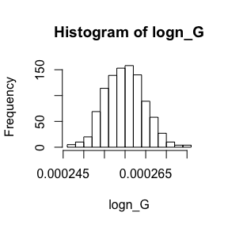

```r
set.seed(436)
### geerate the random numbers, divide to 1000 groups, each group contains 5000 random numbers.

data=matrix(rlnorm(1000*2000,mean=0,sd=1),nrow=2000,ncol=1000)

logn_mean=rep(0,ncol(data)) ## definate the estimator of mean for 1000 times
logn_median=rep(0,ncol(data)) ## defnate the estimator of median for 1000 times
logn_G=rep(0,ncol(data)) ## definate the estimator of G for 1000 times

## repaet 1000 times

for (i in 1:ncol(data)){
  logn_mean[i]=mean(data[,i]) ## compute the sample mean
  data[,i]=sort(data[,i],decreasing=F) ## sort the random number from minimum to maximum.
  logn_median[i]=(data[,i][ncol(data)/2]+data[,i][ncol(data)/2+1])/2 ## compute the sample median

  ##compute the Gini ratio via order statistics
  n=nrow(data)
  d=rep(0,n)
  for(j in 1:n) {
    d[j]=(2*j-n-1)*data[,i][j]
  }
logn_G[i]=mean(d)/(n^2*logn_mean[i])
}
hist(logn_G)
```

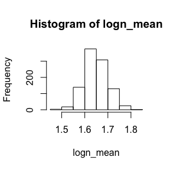

```r
hist(logn_mean)
```

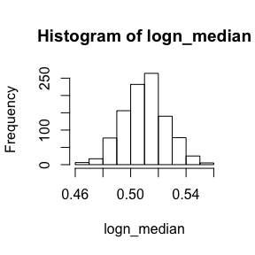

```r
hist(logn_median)
```

now we repeat above code for uniform[0,1]

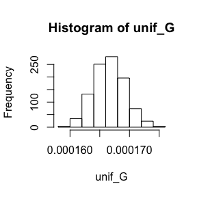

```r
set.seed(1436)
### geerate the random numbers, divide to 1000 groups, each group contains 5000 random numbers.

data=matrix(runif(1000*2000),nrow=2000,ncol=1000)

unif_mean=rep(0,ncol(data)) ## definate the estimator of mean for 1000 times
unif_median=rep(0,ncol(data)) ## defnate the estimator of median for 1000 times
unif_G=rep(0,ncol(data)) ## definate the estimator of G for 1000 times

## repaet 1000 times

for (i in 1:ncol(data)){
  unif_mean[i]=mean(data[,i]) ## compute the sample mean
  data[,i]=sort(data[,i],decreasing=F) ## sort the random number from minimum to maximum.
  unif_median[i]=(data[,i][ncol(data)/2]+data[,i][ncol(data)/2+1])/2 ## compute the sample median

  ##compute the Gini ratio via order statistics
  n=nrow(data)
  d=rep(0,n)
  for(j in 1:n) {
    d[j]=(2*j-n-1)*data[,i][j]
  }
unif_G[i]=mean(d)/(n^2*unif_mean[i])
}
hist(unif_G)
```

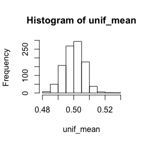

```r
hist(unif_mean)
```

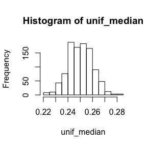

```r
hist(unif_median)
```

for Bernoulli(0.1),the code is also as above.

## Question

### Exercises 6.10

Construct an approximate 95% confidence interval for the Gini ratio $\gamma= E[G]$if $X $is lognormal with unknown parameters. Assess the coverage rate of theestimation procedure with a Monte Carlo experiment.

## Answer

we assume that the parameter $\mu,\sigma$ is unknown so the pdf is
$$p(x)=\frac{1}{x\sigma\sqrt{2\pi}}e^{-\frac{(\log x-\mu)^2}{2\sigma^2}},$$

we use plug-in method to estimate the G. The code is as follow:

```r
## write a function  n denote sample size, m denote repaet times, mu and sigma denote the parameter  in lognorm-distribution

mc_fun=function(n,m,mu,sigma){
  set.seed(528)
  data=matrix(rlnorm(m*n,mu,sigma),nrow=n,ncol=m)
  logn_G=rep(0,m)
  logn_mean=rep(0,m)
  for(i in 1:m){
    logn_mean[i]=mean(data[,i])
     data[,i]=sort(data[,i],decreasing=F) ##sort the random number from minimum to maximum.(obtain the order statistics)

    ##compute the Gini ratio via order statistics]

       d=rep(0,n)
       for(j in 1:n)  d[j]=(2*j-n-1)*data[,i][j]

       logn_G[i]=mean(d)/(n^2*logn_mean[i])
  }
  ##print the sample mean.sample sd,  and 95% CI??
print(c(mean(logn_G),sd(logn_G),mean(logn_G)-2*sd(logn_G),
        mean(logn_G)+2*sd(logn_G)))
}
Gini=mc_fun(1000,1000,1,1)
```

```
## [1] 5.186052e-04 1.272425e-05 4.931567e-04 5.440537e-04
```

According to the result, for $\mu=\sigma=1$,we can conclude that the sample mean is 5.186052e-04, sample sd is 1.272425e-05, 95% CI is [4.931567e-04,5.440537e-04].

## Question

### Exercises 6.B

Tests for association based on Pearson product moment correlation $\rho$, Spearman??srank correlation coefficient $\rho_s$, or Kendall??s coefficient $\tau$, are implemented in cor.test. Show (empirically) that the nonparametric tests based on $\rho_s$ or $\tau$ are less powerful than the correlation test when the sampled distribution is bivariate normal. Find an example of an alternative (a bivariatedistribution (X, Y ) such that X and Y are dependent) such that at least oneof the nonparametric tests have better empirical power than the correlation test against this alternative.

## Answer

we let the null hypotheses is $H_0: \rho=0$, alternative hypotheses is $H_1: \rho\neq 0.$

we use the bivariate normal dinstrbution to simulation, we assume that $\mu_1=\mu_2=0,\sigma_1^2=\sigma_2^2=1,\rho=0.5$

```r
##Simulate from a Multivariate Normal Distribution
library(MASS)
set.seed(4356)
Sigma = matrix(c(1,0.5,0.5,1),2,2)
Sigma
```

```
##      [,1] [,2]
## [1,]  1.0  0.5
## [2,]  0.5  1.0
```

```r
x=mvrnorm(n=1000, rep(0, 2), Sigma)
cor.test(x[,1],x[,2],method='pearson')  ##  person correlation coefficient
```

```
##
##  Pearson's product-moment correlation
##
## data:  x[, 1] and x[, 2]
## t = 16.22, df = 998, p-value < 2.2e-16
## alternative hypothesis: true correlation is not equal to 0
## 95 percent confidence interval:
##  0.4062581 0.5044572
## sample estimates:
##       cor
## 0.4567479
```

```r
cor.test(x[,1],x[,2],method='spearman') ## spearman rank correlation coefficient
```

```
##
##  Spearman's rank correlation rho
##
## data:  x[, 1] and x[, 2]
## S = 95977000, p-value < 2.2e-16
## alternative hypothesis: true rho is not equal to 0
## sample estimates:
##       rho
## 0.4241385
```

```r
cor.test(x[,1],x[,2],method='kendall')  ## kendall correlation coefficient
```

```
##
##  Kendall's rank correlation tau
##
## data:  x[, 1] and x[, 2]
## z = 13.776, p-value < 2.2e-16
## alternative hypothesis: true tau is not equal to 0
## sample estimates:
##       tau
## 0.2909309
```

## Homework 5

## Exercises 7.1

#### Compute a jackknife estimate of the bias and the standard error of the correlation statistic in Example 7.2.

## Answer

```r
set.seed(1)
library(bootstrap)
data=law  # data set
head(data)
```

```
##   LSAT  GPA
## 1  576 3.39
## 2  635 3.30
## 3  558 2.81
## 4  578 3.03
## 5  666 3.44
## 6  580 3.07
```

```r
n=nrow(data)  # sample size
theta.hat=cor(data[,1],data[,2]) # the sample correlation.
#### jackknife
theta.jack=numeric(n)
for (i in 1:n) {   ##leave one out
  data.jack=data[-i,]
  theta.jack[i]=cor(data.jack[,1],data.jack[,2])
}
jack.bias=(n-1)*mean(theta.jack-theta.hat) # jackknife bias
jack.sd=sqrt((n-1)*mean((theta.jack - mean(theta.jack))^2)) # jackknife sd
round(c(theta.hat=theta.hat,theta.jack=mean(theta.jack),
        jack.bias=jack.bias,jack.sd=jack.sd),5)
```

```
##  theta.hat theta.jack  jack.bias    jack.sd
##    0.77637    0.77591   -0.00647    0.14252
```

## Exercises 7.5

#### Refer to Exercise 7.4. Compute 95% bootstrap confidence intervals for the mean time between failures $1/\lambda$ by the standard normal, basic, percentile, and BCa methods. Compare the intervals and explain why they may differ.

## Answer

#### the pdf of exponential distribution is

$$f(x)=\lambda e^{-\lambda x}, x>0,$$
and the mean is $1/\lambda.$

```r
library(boot)
set.seed(1)
#  define a function to compute the boostrap estimator for sample mean.
air.fun <- function(data,i) {
  m <- mean(data$hours[i]) # sample mean
  n <- length(i)
  v <- (n-1)*var(data$hours[i])/n^2 # sample variance
  c(m, v)
}

# use  boot function, repeat 1000 times
air.boot <- boot(aircondit, air.fun, R = 1000)
air.boot #t1 denote sample mean bootstrap, t2 denote sample variance bootstrap
```

```
##
## ORDINARY NONPARAMETRIC BOOTSTRAP
##
##
## Call:
## boot(data = aircondit, statistic = air.fun, R = 1000)
##
##
## Bootstrap Statistics :
##      original    bias    std. error
## t1*  108.0833   1.34350    38.28798
## t2* 1417.7147 -85.66468   881.11158
```

```r
# use boot.ci function to obtain the CI
ci <- boot.ci(air.boot,type=c("norm","basic","perc","bca"))
ci
```

```
## BOOTSTRAP CONFIDENCE INTERVAL CALCULATIONS
## Based on 1000 bootstrap replicates
##
## CALL :
## boot.ci(boot.out = air.boot, type = c("norm", "basic", "perc",
##     "bca"))
##
## Intervals :
## Level      Normal              Basic
## 95%   ( 31.7, 181.8 )   ( 25.8, 170.9 )
##
## Level     Percentile            BCa
## 95%   ( 45.3, 190.4 )   ( 53.3, 214.6 )
## Calculations and Intervals on Original Scale
## Some BCa intervals may be unstable
```

## Exercises 7.8

#### Refer to Exercise 7.7. Obtain the jackknife estimates of bias and standard error of $\hat{\theta}$.

## Answer

```r
library(bootstrap) #loading packages
data=as.matrix(scor) # let data.frame become matrix
head(data)
```

```
##   mec vec alg ana sta
## 1  77  82  67  67  81
## 2  63  78  80  70  81
## 3  75  73  71  66  81
## 4  55  72  63  70  68
## 5  63  63  65  70  63
## 6  53  61  72  64  73
```

```r
n=nrow(data) # sample size
lambda.hat=eigen(t(data)%*%data/n)$values ## sample eigenvalues
theta.hat=lambda.hat[1]/sum(lambda.hat)  ## sample estimator
#### jackknife
theta.jack=numeric(n)
for(i in 1:n){          ##leave one out
  data.jack=data[-i,]
  lambda.jack=eigen(t(data.jack)%*%data.jack/(n-1))$values
  theta.jack[i]=lambda.jack[1]/sum(lambda.jack)
}
jack.bias=(n-1)*mean(theta.jack-theta.hat) #jackknife  bias
jack.sd=sqrt((n-1)*mean((theta.jack - mean(theta.jack))^2)) #jackknife se
round(c(theta.jack=mean(theta.jack),theta.hat=theta.hat,
        jack.bias=jack.bias,jack.sd=jack.sd),7)
```

```
## theta.jack  theta.hat  jack.bias    jack.sd
##  0.9610518  0.9610485  0.0002882  0.0043105
```

## Exercises 7.11

#### In Example 7.18, leave-one-out (n-fold) cross validation was used to select the best fitting model. Use leave-two-out cross validation to compare the models.

## Answer

The sample size of the dataset is 53, we need to randomly sampling 2 obeservations, there have $53\times52/2$ outcomes. Then, we use the n-2 observations as the training data, establish the model, and then use the 2 observations to testing the error.

```r
library(DAAG) # loading packages
data=ironslag #data set
n=nrow(data) # sample size
# creat a matrix to storage the index of test for leave-two-out CV.
index=matrix(nrow=n*(n-1)/2,ncol=2)

#we obtain all the index via random sampling 2 observations,
# there is 53*52/2=1378 outcomes.

a=c(1:n) # index of sample size, is 1:n
l=1
for(i in 1: (n-1)){
  for(j in (i+1):n){
index[l,]=(a[c(i,j)])
l=l+1
  }
}
##
e1= e2 = e3 = e4 = matrix(nrow=nrow(index),ncol=2)

# fit models on leave-two-out samples
for(l in 1:nrow(index)){
  k=index[l,] #the index of testing data
  y=data[-k,2] # the y of training data
  x=data[-k,1] # the x of training data

## linear model
  J1 = lm(y ~ x) # linear model
  yhat1 = J1$coef[1] + J1$coef[2] * data[k,1] # yhat on testing data
  e1[l,] = data[k,2] - yhat1

##quadratic model
  J2 <- lm(y ~ x + I(x^2)) # quadratic model
yhat2 <- J2$coef[1] + J2$coef[2] * data[k,1] + # yhat on testing data
J2$coef[3] * data[k,1]^2
e2[l,] = data[k,2] - yhat2

##Exponential model
J3 = lm(log(y) ~ x) #exp model
logyhat3 =J3$coef[1]+J3$coef[2] * data[k,1] # yhat on testing data
yhat3 <- exp(logyhat3)
e3[l,] = data[k,2] - yhat3

## Log-Log model
  J4 <- lm(log(y) ~ log(x)) # log-log model
  logyhat4 <- J4$coef[1] + J4$coef[2] * log(data[k,1]) # yhat on testing data
  yhat4 <- exp(logyhat4)
  e4[l,] = data[k,2] - yhat4

}
print(c(mse1=mean(e1^2), mse2=mean(e2^2), mse3=mean(e3^2), mse4=mean(e4^2)))
```

```
##     mse1     mse2     mse3     mse4
## 19.57227 17.87018 18.45491 20.46718
```

# Homework 6

## Question 8.1

Implement the two-sample Cramer-von Mises test for equal distributions as a permutation test. Apply the test to the data in Examples 8.1 and 8.2.

## Answer

We implement the two-sample Cramer-von Mises test for equal distributions as following:

```r
cvm.d<-function(x,y){ #compute the Cramer-von Mises statistic
  n<-length(x);m<-length(y)
  Fn<-ecdf(x);Gm<-ecdf(y)
  W2<-((m*n)/(m+n)^2)*
      (sum((Fn(x)-Gm(x))^2)+sum((Fn(y)-Gm(y))^2))
  W2
}
```

Next, we apply the test to the data in Examples 8.1 and 8.2.

```r
library(boot)
attach(chickwts)
x <- sort(as.vector(weight[feed == "soybean"]))
y <- sort(as.vector(weight[feed == "linseed"]))
detach(chickwts)

set.seed(611)
R <- 999 #number of replicates
z <- c(x, y) #pooled sample
n<-length(x)
m<-length(y)
N <- 1:(m+n)
reps <- numeric(R) #storage for replicates
W2 <- cvm.d(x, y)
W2
```

```
## [1] 0.1515216
```

```r
for (i in 1:R) {
#generate indices k for the first sample
k <- sample(N, size = n, replace = FALSE)
x1 <- z[k]
y1 <- z[-k] #complement of x1
reps[i] <- cvm.d(x1, y1)
}
p <- mean(c(W2, reps) >= W2)
p
```

```
## [1] 0.394
```

## Question 9.3

The standard Cauchy has the Cauchy(?? =1,??= 0) density. (Note that the standard Cauchy density is equal to the Student t density with one degree of freedom.)

## Answer

I choose the normal distribution as the proposal distribution of this exercise.

```r
set.seed(1)
f <- function(x, theta,eta) {
  stopifnot(theta > 0)
  return(1/(theta*pi*(1+((x-eta)/theta)^2)))
}
xt <- x[i-1]
y <-  xt+runif(1,-1,1)
m <- 10000
theta <- 1
eta <- 0
x <- numeric(m)
x[1] <- runif(1,-1,1)
k <- 0
u <- runif(m)

for (i in 2:m) {
  xt <- x[i-1]
  y <- xt+runif(1,min=-1,max=1)
  num <- f(y, theta,eta)*dnorm(xt,mean=y,sd=1)
  den <- f(xt, theta,eta)*dnorm(y,mean=xt,sd=1)
  if (u[i] <= num/den) x[i] <- y else {
    x[i] <- xt
    k <- k+1         #y is rejected
  }
}
print(k)
```

```
## [1] 1675
```

In this exercise, approximately 17% of the candidate points are rejected, so the chain is somewhat e???cient.

To see the generated sample as a realization of a stochastic process, we can plot the sample vs the time index. The following code will display a partial plot starting at time index 1500.

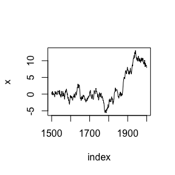

```r
index <- 1500:2000
y1 <- x[index]
plot(index, y1, type="l", main="", ylab="x")
```

The following code compares the quantiles of the target cauchy (1,0) distribution with the quantiles of the generated chain in a quantile-quantile plot (QQ plot).

```r
gene<- quantile(x[-(1:1000)],seq(0.1,0.9,0.1))
empi<-qt(seq(0.1,0.9,0.1),1)
rbind(gene,empi)
```

```
##            10%       20%        30%        40%          50%       60%
## gene -2.569783 -1.272012 -0.7253008 -0.3254927 -0.005523593 0.3115794
## empi -3.077684 -1.376382 -0.7265425 -0.3249197  0.000000000 0.3249197
##            70%      80%      90%
## gene 0.6881670 1.319415 3.312069
## empi 0.7265425 1.376382 3.077684
```

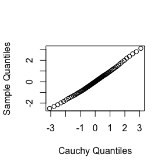

```r
b <- 1001     #discard the burnin sample
y <- x[b:m]
probs <- seq(0.1,0.9,0.01)
QR <- qt(probs,df=1)
Q <- quantile(x, probs)

qqplot(QR, Q, main="",
       xlab="Cauchy Quantiles", ylab="Sample Quantiles")
```

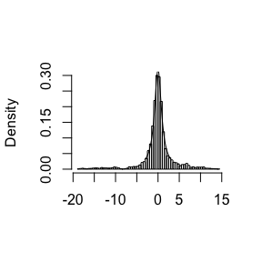

```r
hist(y, breaks="scott", main="", xlab="", freq=FALSE)
lines(QR, f(QR, 1,0))
```

The QQ plot is aninformal approachto assessing the goodness-of-???t of the generated sample with the target distribution. From the plot, it appears that the sample quantiles are in approximate agreement with the theoretical quantiles.

## Answer

```r
set.seed(1)

w <- .25   #width of the uniform support set
m <- 5000  #length of the chain
burn <- 1000  #burn-in time
total <- 197
x <- numeric(m)  #the chain
```

```r
group <- c(125,20,18,34)

prob <- function(y, group) {
  # computes (without the constant) the target density
  if (y < 0 || y >= 1)
    return (0)
  return(((2+y)/4)^group[1] *
           ((1-y)/4)^group[2] * ((1-y)/4)^group[3] *
           ((y/4)^group[4]))
}

u <- runif(m)          #for accept/reject step
v <- runif(m, -w, w)   #proposal distribution
x[1] <- 0.5
for (i in 2:m) {
  y <- x[i-1] + v[i]
  if (u[i] <= prob(y, group) / prob(x[i-1], group))
    x[i] <- y else
      x[i] <- x[i-1]
}
print(group)
```

```
## [1] 125  20  18  34
```

```r
print(round(group/total, 3))
```

```
## [1] 0.635 0.102 0.091 0.173
```

```r
set.seed(1)
 xb <- x[(burn+1):m]
 print(mean(xb))
```

```
## [1] 0.6196245
```

The sample mean of the generated chain is 0.6196245

# Homework 7

#### 1. For exercise 9.6, use the Gelman-Rubin method to monitor convergence of the chain, and run the chain until the chain has converged approximately to the target distribution according to $\hat{R}<1.2$.

#### answer:

The solution for exercise 9.6:

```
## [1] 0.1528
```

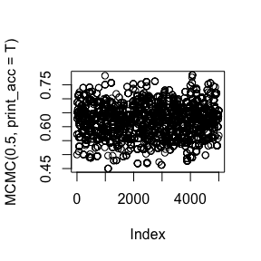

```r
lden=function(theta)125*log(2+theta)+38*log(1-theta)+34*log(theta)
MCMC=function(x,burn_in=0,N=burn_in+5000,print_acc=F){
  y=1:N#for MCMC generation
  ld=lden#use log-likelihood, things could be a little bit different.
  acc=0
  for(i in 1:N){
    p=runif(1)
    y[i]=x=if(runif(1)<exp(ld(p)-ld(x))){acc=acc+1;p}else x
  }
  if(print_acc)print(acc/N)
  y[(burn_in+1):N]
}
plot(MCMC(0.5,print_acc=T))#accept rate~0.15
```

Gelman-Rubin method of monitoring convergence

```r
Gelman.Rubin <- function(psi) {
 # psi[i,j] is the statistic psi(X[i,1:j])
 # for chain in i-th row of X
  psi <- as.matrix(psi)
  n <- ncol(psi)
  k <- nrow(psi)

   psi.means <- rowMeans(psi)     #row means
   B <- n * var(psi.means)        #between variance est.
   psi.w <- apply(psi, 1, "var")  #within variances
  W <- mean(psi.w)               #within est.
  v.hat <- W*(n-1)/n + B/n+(B/(n*k))     #upper variance est.
   r.hat <- v.hat / W             #G-R statistic
return(r.hat)
  }
```

so we could monitor 2 chains.

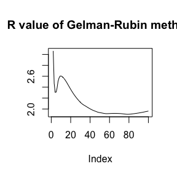

```r
M1=cumsum((MC1=MCMC(0.2)))/1:5000#mean_cumsum
M2=cumsum((MC2=MCMC(0.4)))/1:5000#mean_cumsum
M3=cumsum((MC3=MCMC(0.6)))/1:5000#mean_cumsum
M4=cumsum((MC4=MCMC(0.8)))/1:5000#mean_cumsum
psi=rbind(M1,M2,M3,M4)
plot((R=sapply(1:100,function(i)Gelman.Rubin(psi[,1:i]))),main="R value of Gelman-Rubin method",type='l',ylab = "")
```

```r
res=(1:100)[R[2:100]>1.2][sum(R[2:100]>1.2)]+1
c(mean(c(MC1[res:5000],MC2[res:5000],MC3[res:5000],MC4[res:5000])),
  var(c(MC1[res:5000],MC2[res:5000],MC3[res:5000],MC4[res:5000])))
```

```
## [1] 0.622173447 0.002407439
```

#### 2. Find the intersection points $A(k)$ in $(0,\sqrt{k})$ of the curves

$$S_{k-1}(a)=\left(t(k-1)>\sqrt{\frac{a^2(k-1)}{k-a^2}} \right)$$
and
$$S_{k}(a)=\left(t(k)>\sqrt{\frac{a^2k}{k+1-a^2}} \right)$$
for $k=4:25,100, 500, 1000$, where $t(k)$ is a Student $ t$ random variable with $k$ degrees of freedom.

#### answer:

k=4:25

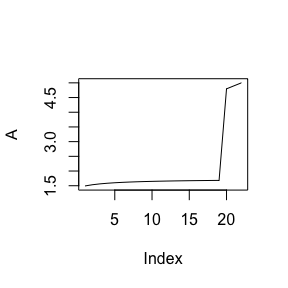

```r
n=25
A=rep(0,length(c(4:n)))
for(k in 4:n){
f=function(x){
pt(sqrt(x^2*k/(k+1-x^2)),k)-pt(sqrt(x^2*(k-1)/(k-x^2)),k-1)}
A[k-3]=uniroot(f,c(0.00001,sqrt(k)-0.00001))$root #solve the intersection points
}
plot(A,type='l')
```

k=4:100

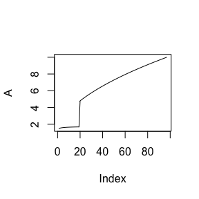

```r
n=100
A=rep(0,length(c(4:n)))
for(k in 4:n){
f=function(x){
pt(sqrt(x^2*k/(k+1-x^2)),k)-pt(sqrt(x^2*(k-1)/(k-x^2)),k-1)}
A[k-3]=uniroot(f,c(0.00001,sqrt(k)-0.00001))$root #solve the intersection points
}
plot(A,type='l')
```

k=4:500

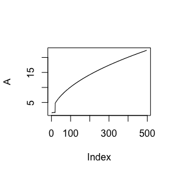

```r
n=500
A=rep(0,length(c(4:n)))
for(k in 4:n){
f=function(x){
pt(sqrt(x^2*k/(k+1-x^2)),k)-pt(sqrt(x^2*(k-1)/(k-x^2)),k-1)}
A[k-3]=uniroot(f,c(0.00001,sqrt(k)-0.00001))$root #solve the intersection points
}
plot(A,type='l')
```

k=4:1000

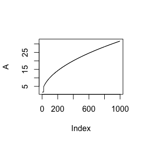

```r
n=1000
A=rep(0,length(c(4:n)))
for(k in 4:n){
f=function(x){
pt(sqrt(x^2*k/(k+1-x^2)),k)-pt(sqrt(x^2*(k-1)/(k-x^2)),k-1)}
A[k-3]=uniroot(f,c(0.00001,sqrt(k)-0.00001))$root #solve the intersection points
}
plot(A,type='l')
```

# Homework 8

- Question 1
- Write a function to compute the cdf of the Cauchy distribution, which has density
  $$\frac{1}{\theta\pi(1+[(x-\eta)/\theta]^2)},\quad -\infty<x<\infty,$$
  where $\theta>0$. Compare your results to the results from the R function pcauchy. (Also see the source code in pcauchy.c.)
- answer

The cdf is
$$F(x)=\int_{-\infty}^x \frac{1}{\theta\pi(1+[(t-\eta)/\theta]^2)}dt.$$
we use the Numerical Integration method to get the pdf.

we let ($\theta,\eta$)=(1,0) and ($\theta,\eta$)=(1,1), $x\in(0,10)$,and compute the cdf for cauchy distribution.

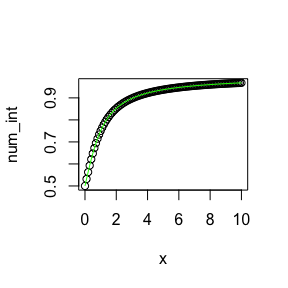

```r
## define the pdf of cauchy distribution
pdf_cauchy=function(t,theta,eta){
  1/(theta*pi*(1+((t-eta)/theta)^2))
}
x=seq(0,10,0.1)
num_int=rep(0,length(x))
p=rep(0,length(x))
# let theta=1,eta=0.
for(i in 1:length(x)){
num_int[i]=integrate(pdf_cauchy, -Inf, x[i],theta=1,eta=0)$value
p[i]=pcauchy(x[i],location = 0, scale = 1) # by pcauchy
}
plot(x,num_int) # plot the num_int
lines(x,p,col='green') # plot the pcauchy
```

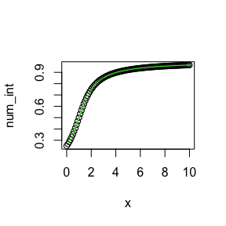

```r
# let theta=1,eta=1.
for(i in 1:length(x)){
num_int[i]=integrate(pdf_cauchy, -Inf, x[i],theta=1,eta=1)$value
p[i]=pcauchy(x[i],location = 1, scale = 1) # by pcauchy
}
plot(x,num_int) # plot the num_int
lines(x,p,col='green') # plot the pcauchy
```

According the graph, we can see that both pcauchy and Numerical Integration method very similar.

# Homework 9

### Question 1.

Use both for loops and lapply() to fit linear models to the mtcars using the formulas stored in this list:

formulas <- list(

mpg ~ disp

mpg ~ I(1 / disp)

mpg~disp+wt

mpg~I(1/disp)+wt

)

### answer

```r
## use loops to fit linear model.
formulas = list(
mpg ~ disp,
mpg ~ I(1 / disp), mpg~disp+wt, mpg~I(1/disp)+wt
)
out1=list()
for(i in 1:4){
  out1[[i]]=lm(formulas[[i]],data=mtcars)
}
out1
```

```
## [[1]]
##
## Call:
## lm(formula = formulas[[i]], data = mtcars)
##
## Coefficients:
## (Intercept)         disp
##    29.59985     -0.04122
##
##
## [[2]]
##
## Call:
## lm(formula = formulas[[i]], data = mtcars)
##
## Coefficients:
## (Intercept)    I(1/disp)
##       10.75      1557.67
##
##
## [[3]]
##
## Call:
## lm(formula = formulas[[i]], data = mtcars)
##
## Coefficients:
## (Intercept)         disp           wt
##    34.96055     -0.01772     -3.35083
##
##
## [[4]]
##
## Call:
## lm(formula = formulas[[i]], data = mtcars)
##
## Coefficients:
## (Intercept)    I(1/disp)           wt
##      19.024     1142.560       -1.798
```

```r
### use lapply() function to fit linear model
out2=lapply(formulas,lm,data=mtcars)
out2
```

```
## [[1]]
##
## Call:
## FUN(formula = X[[i]], data = ..1)
##
## Coefficients:
## (Intercept)         disp
##    29.59985     -0.04122
##
##
## [[2]]
##
## Call:
## FUN(formula = X[[i]], data = ..1)
##
## Coefficients:
## (Intercept)    I(1/disp)
##       10.75      1557.67
##
##
## [[3]]
##
## Call:
## FUN(formula = X[[i]], data = ..1)
##
## Coefficients:
## (Intercept)         disp           wt
##    34.96055     -0.01772     -3.35083
##
##
## [[4]]
##
## Call:
## FUN(formula = X[[i]], data = ..1)
##
## Coefficients:
## (Intercept)    I(1/disp)           wt
##      19.024     1142.560       -1.798
```

### Question 2.

Fit the model mpg ~ disp to each of the bootstrap replicates of mtcars in the list below by using a for loop and lapply(). Can you do it without an anonymous function?

### answer

```r
bootstraps <- lapply(1:10, function(i) {
         rows <- sample(1:nrow(mtcars), rep = TRUE)
         mtcars[rows, ]
})
### loops
out3=list()
for(i in 1:10){
  out3[[i]]=lm(mpg ~ disp,data=bootstraps[[i]])
}
out3
```

```
## [[1]]
##
## Call:
## lm(formula = mpg ~ disp, data = bootstraps[[i]])
##
## Coefficients:
## (Intercept)         disp
##    30.55955     -0.04176
##
##
## [[2]]
##
## Call:
## lm(formula = mpg ~ disp, data = bootstraps[[i]])
##
## Coefficients:
## (Intercept)         disp
##    31.05025     -0.04195
##
##
## [[3]]
##
## Call:
## lm(formula = mpg ~ disp, data = bootstraps[[i]])
##
## Coefficients:
## (Intercept)         disp
##    28.36535     -0.03513
##
##
## [[4]]
##
## Call:
## lm(formula = mpg ~ disp, data = bootstraps[[i]])
##
## Coefficients:
## (Intercept)         disp
##    27.08744     -0.03278
##
##
```

[output cut: 43 more lines]

```
## lm(formula = mpg ~ disp, data = bootstraps[[i]])
##
## Coefficients:
## (Intercept)         disp
##    29.48053     -0.03973
##
##
## [[10]]
##
## Call:
## lm(formula = mpg ~ disp, data = bootstraps[[i]])
##
## Coefficients:
## (Intercept)         disp
##    26.34752     -0.02944
```

```r
### lapply
newdata=list()
for(i in 1:10){

  newdata[[i]]=bootstraps[[i]][,c(1,3)]
}
out4=lapply(newdata,lm)
out4
```

```
## [[1]]
##
## Call:
## FUN(formula = X[[i]])
##
## Coefficients:
## (Intercept)         disp
##    30.55955     -0.04176
##
##
## [[2]]
##
## Call:
## FUN(formula = X[[i]])
##
## Coefficients:
## (Intercept)         disp
##    31.05025     -0.04195
##
##
## [[3]]
##
## Call:
## FUN(formula = X[[i]])
##
## Coefficients:
## (Intercept)         disp
##    28.36535     -0.03513
##
##
## [[4]]
##
## Call:
## FUN(formula = X[[i]])
##
## Coefficients:
## (Intercept)         disp
##    27.08744     -0.03278
##
##
```

[output cut: 43 more lines]

```
## FUN(formula = X[[i]])
##
## Coefficients:
## (Intercept)         disp
##    29.48053     -0.03973
##
##
## [[10]]
##
## Call:
## FUN(formula = X[[i]])
##
## Coefficients:
## (Intercept)         disp
##    26.34752     -0.02944
```

### Question 3

For each model in the previous two exercises, extract R2 using the function below.

### answer

```r
rsq <- function(mod) summary(mod)$r.squared
## compute R2 for out1
R2_1=lapply(out1,rsq)
R2_1
```

```
## [[1]]
## [1] 0.7183433
##
## [[2]]
## [1] 0.8596865
##
## [[3]]
## [1] 0.7809306
##
## [[4]]
## [1] 0.8838038
```

```r
## compute R2 for out2
R2_2=lapply(out2,rsq)
R2_2
```

```
## [[1]]
## [1] 0.7183433
##
## [[2]]
## [1] 0.8596865
##
## [[3]]
## [1] 0.7809306
##
## [[4]]
## [1] 0.8838038
```

```r
## compute R2 for out3
R2_3=lapply(out3,rsq)
R2_3
```

```
## [[1]]
## [1] 0.7519403
##
## [[2]]
## [1] 0.7036879
##
## [[3]]
## [1] 0.6884218
##
## [[4]]
## [1] 0.659451
##
## [[5]]
## [1] 0.770626
##
## [[6]]
## [1] 0.8042041
##
## [[7]]
## [1] 0.7315136
##
## [[8]]
## [1] 0.6851977
##
## [[9]]
## [1] 0.6939635
##
## [[10]]
## [1] 0.592559
```

```r
## compute R2 for out4
R2_4=lapply(out4,rsq)
R2_4
```

```
## [[1]]
## [1] 0.7519403
##
## [[2]]
## [1] 0.7036879
##
## [[3]]
## [1] 0.6884218
##
## [[4]]
## [1] 0.659451
##
## [[5]]
## [1] 0.770626
##
## [[6]]
## [1] 0.8042041
##
## [[7]]
## [1] 0.7315136
##
## [[8]]
## [1] 0.6851977
##
## [[9]]
## [1] 0.6939635
##
## [[10]]
## [1] 0.592559
```

### Question 4

The following code simulates the performance of a t-test for non-normal data. Use sapply() and an anonymous function to extract the p-value from every trial.

### answer

```r
trials <- replicate(
         100,
         t.test(rpois(10, 10), rpois(7, 10)),
         simplify = FALSE
       )
## define a function to extract p.value
p_fun=function(f)(f$p.value)
sapply(trials,p_fun)
```

```
##   [1] 0.94940081 0.42812371 0.07880006 0.86889327 0.66446092 0.04396164
##   [7] 0.93935021 0.91883267 0.48561645 0.85232188 0.55391886 0.09275408
##  [13] 0.25120957 0.60377024 0.39790788 0.51927203 0.20133226 0.91482450
##  [19] 1.00000000 0.66559103 0.45184737 0.46383858 0.93348820 0.65580547
##  [25] 0.66093900 0.37793891 0.89489045 0.70162968 0.88154189 0.94803792
##  [31] 0.72654958 0.74439932 0.40445794 0.83981165 0.30203370 0.64649518
##  [37] 0.04828768 0.42750969 0.93242678 0.32211742 0.45161654 0.59023514
##  [43] 0.37517691 0.14319646 0.14046779 0.53879958 0.80541991 0.29689186
##  [49] 0.19413107 0.98321089 0.23813741 0.17107844 0.51860536 0.46154318
##  [55] 0.25642310 0.90511200 0.20075273 0.93094516 0.98978418 0.45816382
##  [61] 0.36527380 0.11420648 0.20900532 0.48545455 0.30939707 0.43194956
##  [67] 0.30323822 0.19927348 0.93758661 0.74886540 0.78403580 0.83251184
##  [73] 0.07237711 0.73570308 0.12601214 0.58699834 0.91944116 0.60658440
##  [79] 0.20186492 0.78322504 0.32580258 0.92447163 0.48380082 0.73048763
##  [85] 0.07339455 0.30245087 0.81019841 0.18518625 0.21247595 0.06417224
##  [91] 0.42217901 0.67186712 0.75170818 0.61577663 0.02860483 0.37822807
##  [97] 0.03362058 0.99255141 0.66295496 0.59194965
```

# Homework 10

### Question 1

Make a faster version of chisq.test( ) that only computes the chi-square test statistic when the input is two numeric vectors with no missing values.

### answer

In R, the function of chisq.test() as follow. let chisq.test1 denote chisq.test( ), we will try simplifying chisq.test( ).

```r
chisq.test1=function (x, y = NULL, correct = TRUE, p = rep(1/length(x), length(x)),
    rescale.p = FALSE, simulate.p.value = FALSE, B = 2000)
{
    DNAME <- deparse(substitute(x))
    if (is.data.frame(x))
        x <- as.matrix(x)
    if (is.matrix(x)) {
        if (min(dim(x)) == 1L)
            x <- as.vector(x)
    }
    if (!is.matrix(x) && !is.null(y)) {
        if (length(x) != length(y))
            stop("'x' and 'y' must have the same length")
        DNAME2 <- deparse(substitute(y))
        xname <- if (length(DNAME) > 1L || nchar(DNAME, "w") >
            30)
            ""
        else DNAME
        yname <- if (length(DNAME2) > 1L || nchar(DNAME2, "w") >
            30)
            ""
        else DNAME2
        OK <- complete.cases(x, y)
        x <- factor(x[OK])
        y <- factor(y[OK])
        if ((nlevels(x) < 2L) || (nlevels(y) < 2L))
            stop("'x' and 'y' must have at least 2 levels")
        x <- table(x, y)
        names(dimnames(x)) <- c(xname, yname)
        DNAME <- paste(paste(DNAME, collapse = "\n"), "and",
            paste(DNAME2, collapse = "\n"))
    }
    if (any(x < 0) || anyNA(x))
        stop("all entries of 'x' must be nonnegative and finite")
    if ((n <- sum(x)) == 0)
        stop("at least one entry of 'x' must be positive")
    if (simulate.p.value) {
        setMETH <- function() METHOD <<- paste(METHOD, "with simulated p-value\n\t (based on",
            B, "replicates)")
        almost.1 <- 1 - 64 * .Machine$double.eps
    }
    if (is.matrix(x)) {
        METHOD <- "Pearson's Chi-squared test"
        nr <- as.integer(nrow(x))
        nc <- as.integer(ncol(x))
        if (is.na(nr) || is.na(nc) || is.na(nr * nc))
            stop("invalid nrow(x) or ncol(x)", domain = NA)
        sr <- rowSums(x)
        sc <- colSums(x)
        E <- outer(sr, sc, "*")/n
        v <- function(r, c, n) c * r * (n - r) * (n - c)/n^3
        V <- outer(sr, sc, v, n)
        dimnames(E) <- dimnames(x)
        if (simulate.p.value && all(sr > 0) && all(sc > 0)) {
            setMETH()
            tmp <- .Call(C_chisq_sim, sr, sc, B, E)
            STATISTIC <- sum(sort((x - E)^2/E, decreasing = TRUE))
            PARAMETER <- NA
            PVAL <- (1 + sum(tmp >= almost.1 * STATISTIC))/(B +
                1)
        }
        else {
            if (simulate.p.value)
                warning("cannot compute simulated p-value with zero marginals")
            if (correct && nrow(x) == 2L && ncol(x) == 2L) {
                YATES <- min(0.5, abs(x - E))
                if (YATES > 0)
                  METHOD <- paste(METHOD, "with Yates' continuity correction")
            }
            else YATES <- 0
            STATISTIC <- sum((abs(x - E) - YATES)^2/E)
            PARAMETER <- (nr - 1L) * (nc - 1L)
            PVAL <- pchisq(STATISTIC, PARAMETER, lower.tail = FALSE)
        }
    }
    else {
        if (length(dim(x)) > 2L)
            stop("invalid 'x'")
        if (length(x) == 1L)
            stop("'x' must at least have 2 elements")
        if (length(x) != length(p))
            stop("'x' and 'p' must have the same number of elements")
        if (any(p < 0))
            stop("probabilities must be non-negative.")
        if (abs(sum(p) - 1) > sqrt(.Machine$double.eps)) {
            if (rescale.p)
                p <- p/sum(p)
            else stop("probabilities must sum to 1.")
        }
        METHOD <- "Chi-squared test for given probabilities"
        E <- n * p
        V <- n * p * (1 - p)
        STATISTIC <- sum((x - E)^2/E)
        names(E) <- names(x)
        if (simulate.p.value) {
            setMETH()
            nx <- length(x)
            sm <- matrix(sample.int(nx, B * n, TRUE, prob = p),
                nrow = n)
            ss <- apply(sm, 2L, function(x, E, k) {
                sum((table(factor(x, levels = 1L:k)) - E)^2/E)
            }, E = E, k = nx)
            PARAMETER <- NA
            PVAL <- (1 + sum(ss >= almost.1 * STATISTIC))/(B +
                1)
        }
        else {
            PARAMETER <- length(x) - 1
            PVAL <- pchisq(STATISTIC, PARAMETER, lower.tail = FALSE)
        }
    }
    names(STATISTIC) <- "X-squared"
    names(PARAMETER) <- "df"
    if (any(E < 5) && is.finite(PARAMETER))
        warning("Chi-squared approximation may be incorrect")
    structure(list(statistic = STATISTIC, parameter = PARAMETER,
        p.value = PVAL, method = METHOD, data.name = DNAME, observed = x,
        expected = E, residuals = (x - E)/sqrt(E), stdres = (x -
            E)/sqrt(V)), class = "htest")
}
```

Because the input is two numeric vectors with no missing values.

Firstly, this allows me to remove the is.data.frame( ) and is.matrix( ) test.

```r
chisq.test2=function (x, y)
{
  if (length(x) != length(y))
  stop("'x' and 'y' must have the same length")
  OK <- complete.cases(x, y)
        x <- factor(x[OK])
        y <- factor(y[OK])
        if ((nlevels(x) < 2L) || (nlevels(y) < 2L))
            stop("'x' and 'y' must have at least 2 levels")
        x <- table(x, y)
        n <- sum(x)
        p = rep(1/length(x), length(x))
        p <- p/sum(p)


        sr <- rowSums(x)
        sc <- colSums(x)
        E <- outer(sr, sc, "*")/n
        v <- function(r, c, n) c * r * (n - r) * (n - c)/n^3
        V <- outer(sr, sc, v, n)
        dimnames(E) <- dimnames(x)
        STATISTIC <- sum(sort((x - E)^2/E, decreasing = TRUE))
         STATISTIC

}

options(warn=-1)
x <- c(89,37,30,28,2,14,25)
y <- c(29,47,10,8,14,32,52)

chisq.test1(x,y)$statistic
```

```
## X-squared
##        42
```

```r
chisq.test2(x,y)
```

```
## [1] 42
```

```r
library(microbenchmark)
microbenchmark(
  chisq.test1(x,y)$statistic,
  chisq.test2(x,y)
)
```

```
## Unit: microseconds
##                         expr     min      lq     mean   median       uq
##  chisq.test1(x, y)$statistic 489.147 503.027 524.3365 510.7655 526.0725
##            chisq.test2(x, y) 255.125 268.226 291.1734 281.1840 296.5605
##      max neval
##  677.752   100
##  631.315   100
```

It can be seen that chisq.test2( ) is much faster than chisq.test1( ) as twice.